# Advanced Bioinformatics 2026 Assessment

2507525

2026-03-23

## Task 3.1

Using the sum() function and : operator, write an expression to evaluate the sum of all integers between 5 and 55

```r
# use the : operator to create a sequence of integers between 5 and 55
# use sum() function to sum these integers
sum(5:55)
```

```
## [1] 1530
```

## Task 3.2

Write a function called sumfun with one input parameter, called n, that calculates the sum of all integers between 5 and n. Use the function to do the calculation for n = 10, n = 20, and n = 100

```r
# defining a function called sumfun with one input n
# the function uses the : operator to generate a sequence of integers from 5 to n and sum them with sum()
sumfun <- function(n) {sum(5:n)}
# when n = 10 the function will sum all integers from 5 to 10
sumfun (10)
```

```
## [1] 45
```

```r
# the function can be used with any value of n
sumfun(20)
```

```
## [1] 200
```

```r
sumfun(100)
```

```
## [1] 5040
```

## Task 3.3

Write an R script using a for loop to calculate and print out the first 12 entries of the Fibonacci series

```r
# creating empty vector with a length of 12 with numeric(12)
fibonacci <- numeric(12)
# define the first two numbers in the sequence as the first two numbers in the fibonacci sequence
fibonacci[1] <- 1
fibonacci[2] <- 1
# creating a for loop to print the next 10 numbers in the sequence
# as the first 2 numbers have already been defined the loop starts at the 3rd value
for (i in 3:12) {
# in the fibonacci sequence, each number is the sum of the two preceeding numbers in the sequence
  fibonacci[i] <- fibonacci[i-1] + fibonacci[i-2]}
# print the sequence
fibonacci
```

```
##  [1]   1   1   2   3   5   8  13  21  34  55  89 144
```

## Task 3.4

With the mtcars dataset bundled with R, use ggplot to generate a boxplot of miles per gallon (in the variable mpg) as a function of the number of gears (in the variable gear). Use the fill aesthetic to colour boxplots by number of gears.

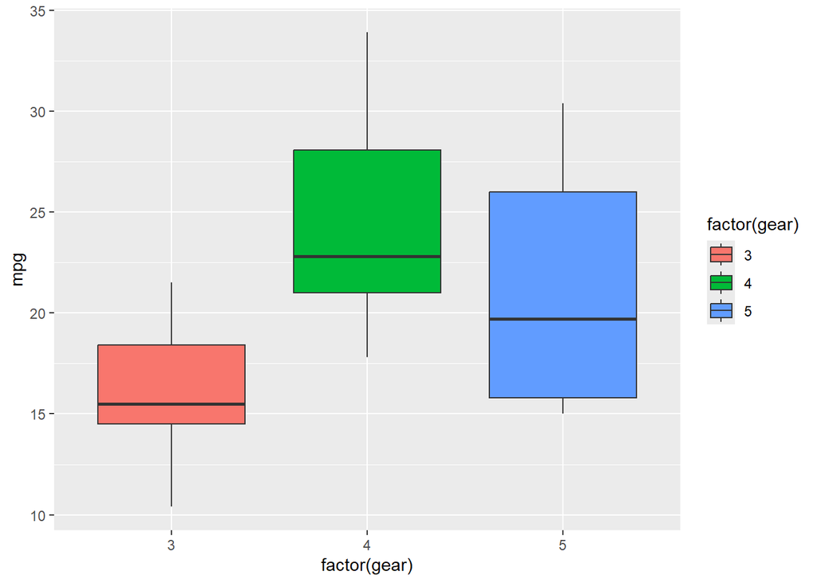

```r
# create a boxplot of mpg grouped by number of gears
ggplot(mtcars, aes(x=factor(gear), y=mpg, fill=factor(gear))) + geom_boxplot() # use mtcars dataset and map number of gears to the x-axis, miles per gallon (mpg) to the y-axis, and colour (fill) by gear group
```

## Task 3.5

Using the cars dataset and the function lm, fit a linear relationship between speed and breaking distance in the variable distance. What are the fitted slope and intercept of the line, and their standard errors?

```r
# check the names in the dataset
names(cars)
```

```
## [1] "speed" "dist"
```

```r
# fit linear model
fit <- lm(dist ~ speed, data = cars)
# view summary
summary(fit)
```

```
##
## Call:
## lm(formula = dist ~ speed, data = cars)
##
## Residuals:
##     Min      1Q  Median      3Q     Max
## -29.069  -9.525  -2.272   9.215  43.201
##
## Coefficients:
##             Estimate Std. Error t value Pr(>|t|)
## (Intercept) -17.5791     6.7584  -2.601   0.0123 *
## speed         3.9324     0.4155   9.464 1.49e-12 ***
## ---
## Signif. codes:  0 '***' 0.001 '**' 0.01 '*' 0.05 '.' 0.1 ' ' 1
##
## Residual standard error: 15.38 on 48 degrees of freedom
## Multiple R-squared:  0.6511, Adjusted R-squared:  0.6438
## F-statistic: 89.57 on 1 and 48 DF,  p-value: 1.49e-12
```

```r
# from summary intercept = -17.5791 with Std error 6.7584
# fitted slope = 3.9324 with Std error 0.4155
```

What are the units used for the variables in the dataset?

```r
# view dataset information to see what units are used
?cars
```

```
## starting httpd help server ... done
```

```r
# the units used for speed is (mph) and the unit used for stopping distance is (ft)
```

## Task 3.6

Use ggplot to plot the data points from Task 3.5 and the linear fit.

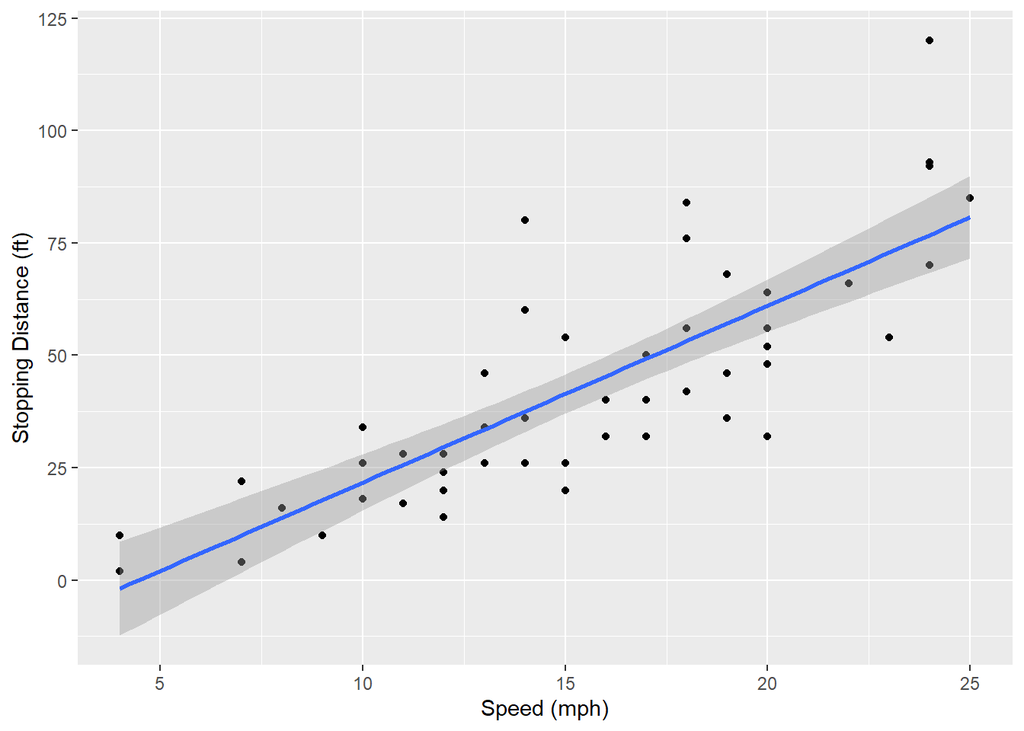

```r
# plot stopping distance against speed and add the fitted linear regression line
ggplot(cars, aes(x = speed, y = dist)) + # use the cars dataset and map speed to the x-axis and distance to the y-axis
  geom_point() + # plot raw data points
  geom_smooth(method = "lm") + # add fitted linear regression line
  labs(x = "Speed (mph)", y = "Stopping Distance (ft)")
```

## Task 3.7

Using the cars dataset, now use linear regression (lm) to estimate the average reaction time for the driver to start braking (in seconds). To simplify matters you may assume that once braking commences, braking distance is proportional to the square of the speed. Explain the steps in your analysis. Do you get reasonable results? Finally, use ggplot to plot the data points and the fitted relationship

```r
# we now need a quadratic model
# reaction distance is proportional to speed and braking distance is proportional to speed squared
# and total stopping distance = reaction distance + braking distance
newfit <- lm(dist ~ speed + I(speed^2), data = cars)
# view summary
summary (newfit)
```

```
##
## Call:
## lm(formula = dist ~ speed + I(speed^2), data = cars)
##
## Residuals:
##     Min      1Q  Median      3Q     Max
## -28.720  -9.184  -3.188   4.628  45.152
##
## Coefficients:
##             Estimate Std. Error t value Pr(>|t|)
## (Intercept)  2.47014   14.81716   0.167    0.868
## speed        0.91329    2.03422   0.449    0.656
## I(speed^2)   0.09996    0.06597   1.515    0.136
##
## Residual standard error: 15.18 on 47 degrees of freedom
## Multiple R-squared:  0.6673, Adjusted R-squared:  0.6532
## F-statistic: 47.14 on 2 and 47 DF,  p-value: 5.852e-12
```

The given reaction time is 0.91329 in ft/mph. To convert this into seconds for ‘reaction time in seconds’ we must convert from mph to ft/s. To do this divide by 1.467 as 1 mph = 1.467 ft/s.

0.91329 / 1.467 = an average reaction time of 0.62 seconds

This seems to be a reasonable average reaction time for braking. Average reaction time for braking is usually estimated between 0.5-1.5 seconds. However, the standard error is large, indicating that the result is not reliable, and neither speed or speed^2 coefficients are statistically significant.

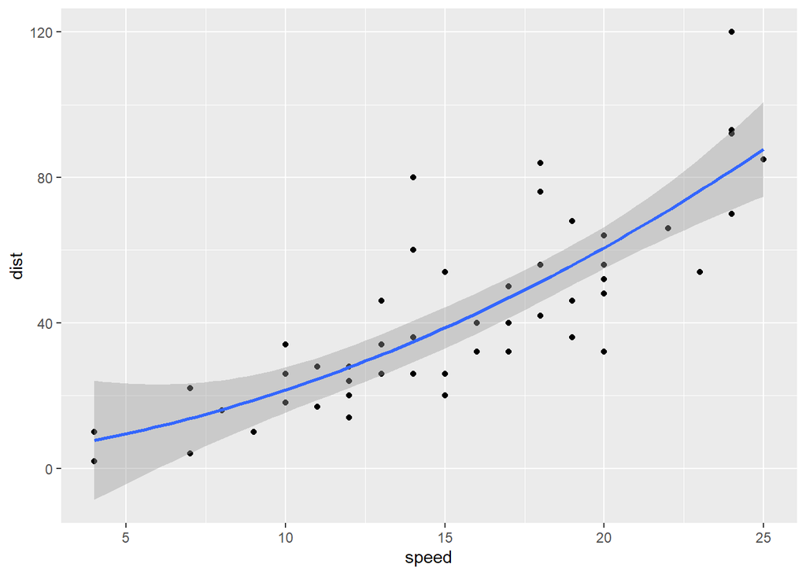

```r
# to create the graph use the same code as before, but specify that it is a quadratic model
ggplot (cars, aes(x = speed, y = dist)) + geom_point() + geom_smooth(method = "lm", formula = y ~ x + I(x^2))
```

## PART 2: RNASEQ

## Task 3.8

Read in count data and sample description.

```r
# read in the count matrix and sample metadata
# header = TRUE uses the first row as column names and row.names = 1 sets the first column as row names
counts <- read.csv("exercise1_counts.csv", row.names = 1)
sample_info <- read.delim("exercise1_sample_description.info", header = TRUE, row.names = 1)

# exploring data

# display the column names of the count matrix
colnames(counts)
```

```
## [1] "control_FFa1.bam" "control_FFa2.bam" "control_FFa3.bam" "mutant_KOa1.bam"
## [5] "mutant_KOa2.bam"  "mutant_KOa3.bam"  "mutant_KOb1.bam"  "mutant_KOb2.bam"
## [9] "mutant_KOb3.bam"
```

```r
# display the row names of the metadata
rownames(sample_info)
```

```
## [1] "control_FFa1.bam"    "control_FFa2.bam"    "control_FFa3.bam"
## [4] "TMC_mutant_KOa1.bam" "TMC_mutant_KOa2.bam" "TMC_mutant_KOa3.bam"
## [7] "TMC_mutant_KOb1.bam" "TMC_mutant_KOb2.bam" "TMC_mutant_KOb3.bam"
```

```r
# examine the full metadata table
sample_info
```

```
##                     sample condition batch
## control_FFa1.bam      FFa1       FFa     a
## control_FFa2.bam      FFa2       FFa     b
## control_FFa3.bam      FFa3       FFa     c
## TMC_mutant_KOa1.bam   KOa1       KOa     a
## TMC_mutant_KOa2.bam   KOa2       KOa     b
## TMC_mutant_KOa3.bam   KOa3       KOa     c
## TMC_mutant_KOb1.bam   KOb1       KOb     a
## TMC_mutant_KOb2.bam   KOb2       KOb     b
## TMC_mutant_KOb3.bam   KOb3       KOb     c
```

```r
# examine the first few rows of the count matrix
head(counts)
```

```
##           control_FFa1.bam control_FFa2.bam control_FFa3.bam mutant_KOa1.bam
## 497097                  16               16                0              21
## 100503874               20                0                0              64
## 100038431                0                0                2               0
## 19888                   11                0               10             113
## 20671                   14               16                0              40
## 27395                  465              193              596             436
##           mutant_KOa2.bam mutant_KOa3.bam mutant_KOb1.bam mutant_KOb2.bam
## 497097                 16              27              20               0
## 100503874               0               4               5               0
## 100038431               0               8               0               0
## 19888                   0              26              14               6
## 20671                   8              33              33              12
## 27395                 686             572            1378            1901
##           mutant_KOb3.bam
## 497097                  2
## 100503874               2
## 100038431               0
## 19888                  16
## 20671                  24
## 27395                1553
```

## Task 3.9

Create col_data and check dimensions

```r
## create col_data from sample metadata
col_data <- sample_info

## check dimensions of metadata and count matrix
dim(col_data)
```

```
## [1] 9 3
```

```r
dim(counts)
```

```
## [1] 26301     9
```

## Task 3.10

Construct DESeqDataSet object using count data and sample description

```r
# aligning the row names of col_data with the column names of the count matrix
# this assumes all samples are in the same order (the metadata and count data must already be aligned or they will become mislabelled)
rownames(col_data) <- colnames(counts)
# constructing DESeq from count matrix and sample desc
# design = ~ condition specifies that condition is the variable of interest
dds <- DESeqDataSetFromMatrix(countData = counts, colData = col_data, design = ~ condition)
```

## Task 3.11

Perform rlog and VST transformation on the data.

```r
# rlog transformation to stabilise variance across genes
# blind = TRUE means DESeq2 will ignore experimental conditions when transforming data
# assay() extracts the transformed matrix (in this case from the rlog object)
rld <- rlog(dds, blind = TRUE)
rld_counts <- assay(rld)
class(rld_counts)
```

```
## [1] "matrix" "array"
```

```r
# vst transformation for similar variance normalisation
vsd <- vst(dds, blind = TRUE)
vsd_counts <- assay(vsd)
class(vsd_counts)
```

```
## [1] "matrix" "array"
```

```r
# Transforming the data reduces noise and improves visualisation/interpretation
```

## Task 3.12

Draw a heatmap of count matrix based on the top 40 highly expressed genes using rlog and VST data.

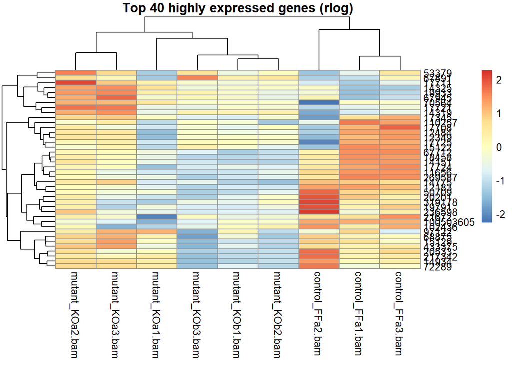

```r
# finding the top 40 highly expressed genes from rlog
# rank genes by their mean rlog expression across all samples and 40 genes with highest average expression selected
top40_rlog <- order(rowMeans(rld_counts), decreasing = TRUE)[1:40]
# visualise with pheatmap
pheatmap(rld_counts[top40_rlog, ], scale = "row", main = "Top 40 highly expressed genes (rlog)")
```

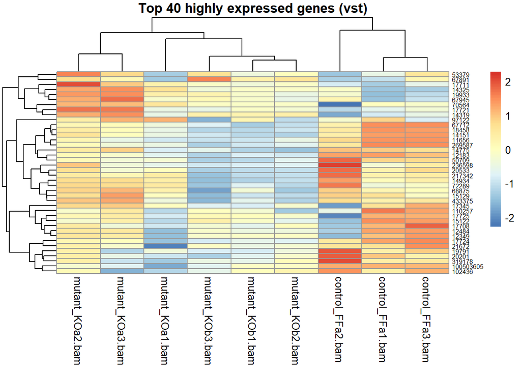

```r
# top 40 highly expressed genes from vst
top40_vst <- order(rowMeans(vsd_counts), decreasing = TRUE)[1:40]
# visualise with pheatmap
pheatmap(vsd_counts[top40_vst, ], scale = "row", fontsize_row = 6, main = "Top 40 highly expressed genes (vst)")
```

```r
# the vst and rlog heat maps shows how expression of the top 40 genes varies across samples
# relative to its own average expression
```

## Task 3.13

Generate a SDM to see the clustering of count data.

```r
# calculate distances between samples (sdm) using the rlog-transformed data
sample_dist <- dist(t(assay(rld)))
class(sample_dist)
```

```
## [1] "dist"
```

```r
# convert into matrix for heatmap visualization
sdm <- as.matrix(sample_dist)
class(sdm)
```

```
## [1] "matrix" "array"
```

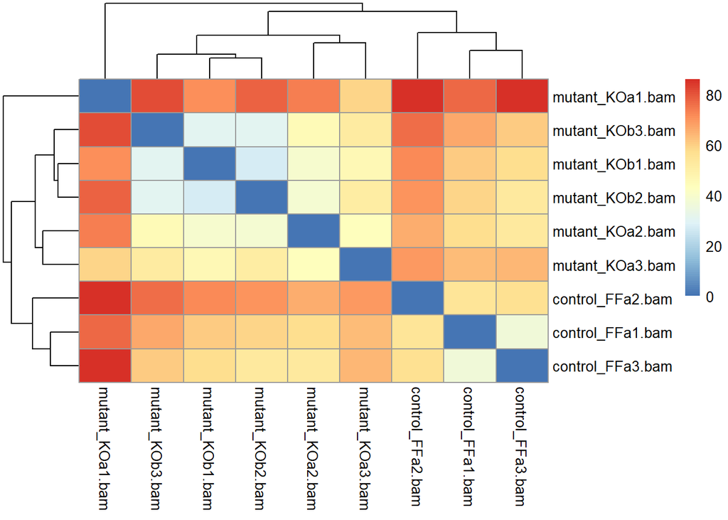

```r
# visualize
pheatmap(sdm)
```

## Task 3.14

Perform PCA analysis using the rlog method and find out the % significance values of first two principal components.

```r
# check what column name is
colnames(colData(rld))
```

```
## [1] "sample"     "condition"  "batch"      "sizeFactor"
```

```
## using ntop=500 top features by variance
```

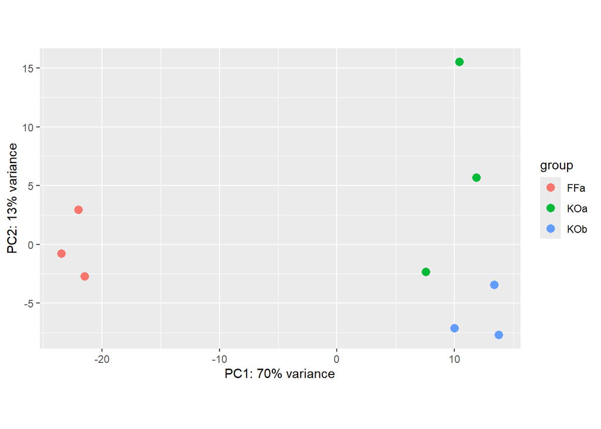

```r
# plot the PCA with rlog data
# PCA reduces dimensions/complexity in data by transforming it into principal components
# PC1 will capture the most variation, then PC2, etc
plotPCA(rld, intgroup = "condition")
```

PCA was performed on the rlog-transformed data using plotPCA(). From the PCA plot, the first principal component explained 70% of the variance and the second principal component explained 13%.

## Task 3.15

Repeat the PCA, this time using VST method and compare the plots with the ones obtained using rlog method

```
## using ntop=500 top features by variance
```

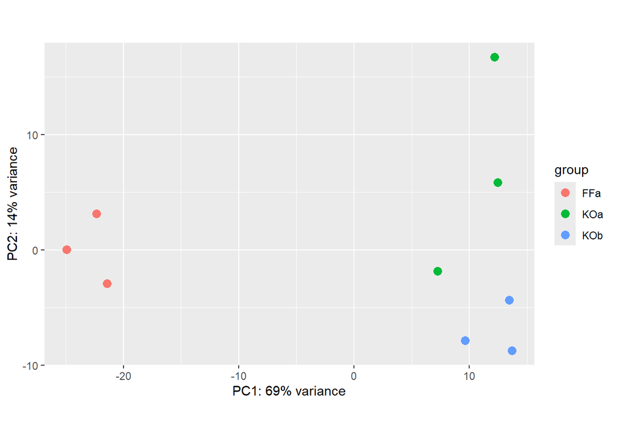

```r
# plot the PCA with vst data
plotPCA(vsd, intgroup = "condition")
```

Comparing the two plots, they are visually similar. Both show the same clustering of samples. However, the vst plot did show a 1% decrease in variance explained by PC1 and a 1% increase in variance explained by PC2.